# Customer Churn Prediction Project

Yezi Liu

2023-10-30

## Project Summary

#### Introduction

This notebook is to analyze a company’s consumer purchase history and use machine learning models to predict whether a customer will churn(abandon the brand) in the future.

#### Business Case

It’s for marketing managers to plan a new campaign designed to increase customer retention. The plan is to deliver the campaign to a targeted audience defined as customers who are likely to abandon the brand within six months. So a model needs to be developed to identify these customers.

#### Dataset

The dataset provided is a snapshot of consumer purchase history taken in mid-June. Customers who made no additional purchases during the six months following the snapshot period were assigned a `churn` value of 1, to indicate that they had abandoned the brand.

Note: No data dictionary was given with this dataset. So the models built in this project were only based on the information that is been provided.

#### Project Sections

1. Import Data
2. Basic Data Cleaning
3. EDA
- Univariate Analysis
- Bivariate Analysis
- XY Relationships Analysis
4. Pre-processing/Feature Engineering
5. Model Selection
- Logistic Regression
- Random Forest
- Model Comparison
- Find Optimal Random Forest Model via Hyper-parameter Tuning
- Build Optimal RF Model with Best Hyper-parameters
6. Model Evaluation
7. Prediction

#### Author & Platform

Yezi Liu conducted this project independently using R Studio.

```r
install.packages("readr")
```

```r
install.packages("ggplot2")
install.packages("dplyr")
install.packages("corrplot")
install.packages("tidyr")
install.packages("caret")
install.packages("MLmetrics")
install.packages("randomForest")
install.packages("e1071")
library(readr)
library(ggplot2)
library(dplyr)
library(corrplot)
library(tidyr)
library(caret)
library(MLmetrics)
library(randomForest)
library(e1071)
set.seed(123)
```

## Import Data

```r
customer_data <- read_csv("/Users/lize/Desktop/DBC/Under Armour/train.csv")
summary(customer_data)
```

```
##  last_purchase     max_discount       shoe_spend    apparell_spend
##  Min.   :  0.00   Min.   :0.00000   Min.   : 65.0   Min.   :  1.2
##  1st Qu.: 57.62   1st Qu.:0.00000   1st Qu.:208.5   1st Qu.:136.6
##  Median : 71.50   Median :0.00000   Median :245.3   Median :171.2
##  Mean   : 70.96   Mean   :0.08142   Mean   :245.6   Mean   :171.4
##  3rd Qu.: 84.50   3rd Qu.:0.20000   3rd Qu.:282.7   3rd Qu.:206.3
##  Max.   :121.00   Max.   :0.50000   Max.   :411.8   Max.   :331.8
##                   NA's   :1                         NA's   :1
##    acc_spend     custserv_calls      churn        acc_purchasers
##  Min.   :  0.0   Min.   :0.000   Min.   :0.0000   Min.   :0.00000
##  1st Qu.: 85.0   1st Qu.:1.000   1st Qu.:0.0000   1st Qu.:0.00000
##  Median :103.0   Median :1.000   Median :0.0000   Median :0.00000
##  Mean   :102.4   Mean   :1.556   Mean   :0.1493   Mean   :0.09752
##  3rd Qu.:121.0   3rd Qu.:2.000   3rd Qu.:0.0000   3rd Qu.:0.00000
##  Max.   :200.0   Max.   :9.000   Max.   :1.0000   Max.   :1.00000
##
##  promo_purchaser   shoe_orders    apparel_orders   acc_orders
##  Min.   :0.0000   Min.   :1.000   Min.   :1.00   Min.   :0.000
##  1st Qu.:0.0000   1st Qu.:2.000   1st Qu.:2.00   1st Qu.:3.000
##  Median :0.0000   Median :2.000   Median :2.00   Median :3.000
##  Mean   :0.2779   Mean   :2.044   Mean   :2.16   Mean   :3.252
##  3rd Qu.:1.0000   3rd Qu.:2.000   3rd Qu.:2.00   3rd Qu.:4.000
##  Max.   :1.0000   Max.   :3.000   Max.   :3.00   Max.   :6.000
##
##     gender          ecommShopper    bhShopper          state
##  Length:2666        Mode :logical   Mode :logical   Length:2666
##  Class :character   FALSE:1871      FALSE:816       Class :character
##  Mode  :character   TRUE :795       TRUE :1850      Mode  :character
##
##
##
##
##    area_code        phone
##  Min.   :408.0   Length:2666
##  1st Qu.:415.0   Class :character
##  Median :415.0   Mode  :character
##  Mean   :437.7
##  3rd Qu.:510.0
##  Max.   :510.0
##
```

There are no uncommon or extreme values in the data set and the type of each variable is reasonable.

## Basic Data Cleaning

```r
# Remove duplicate and NA values
customer_data <- distinct(customer_data)
customer_data <- na.omit(customer_data)
```

## EDA

### Univariate Analysis

#### X Variables

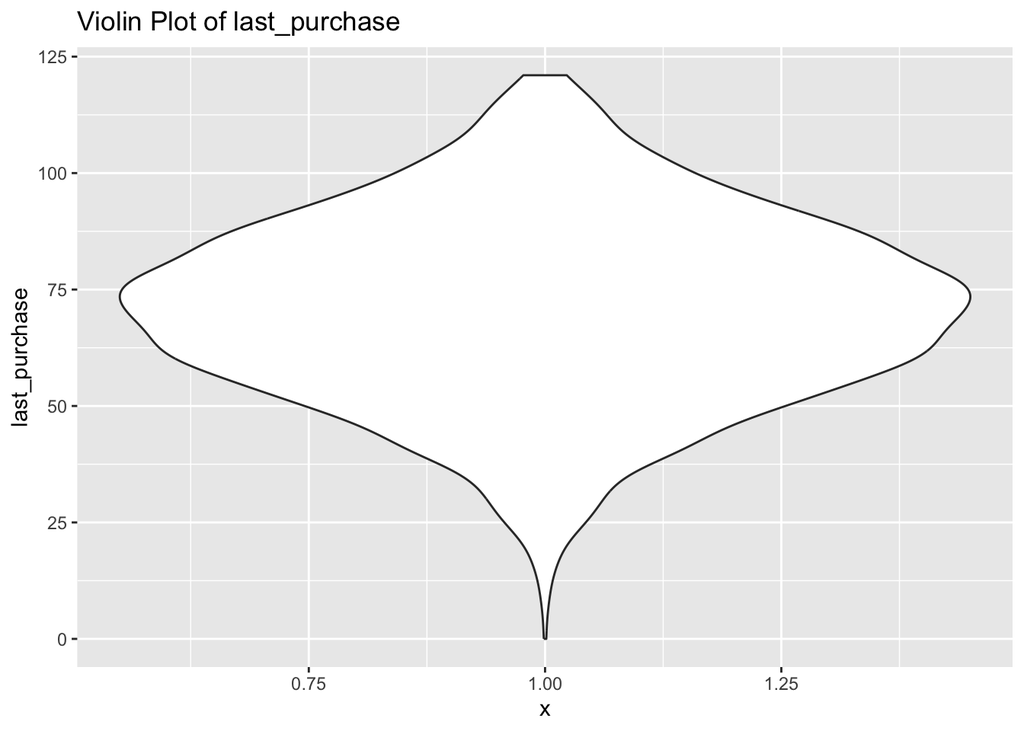

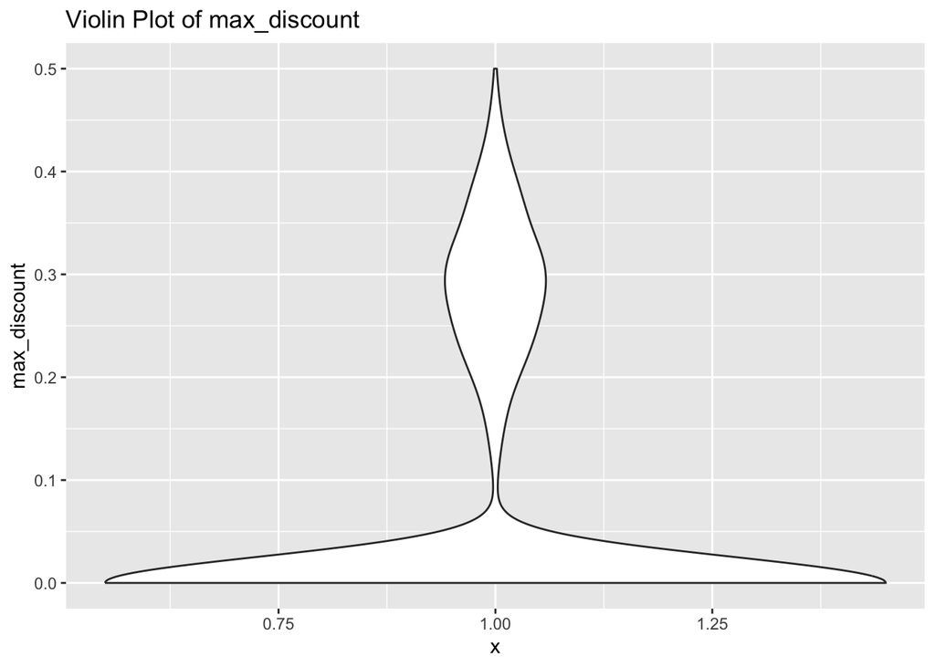

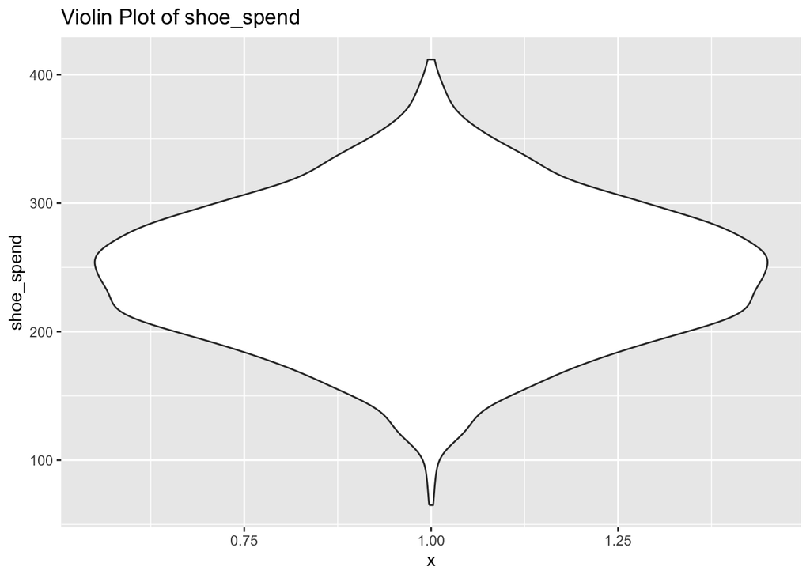

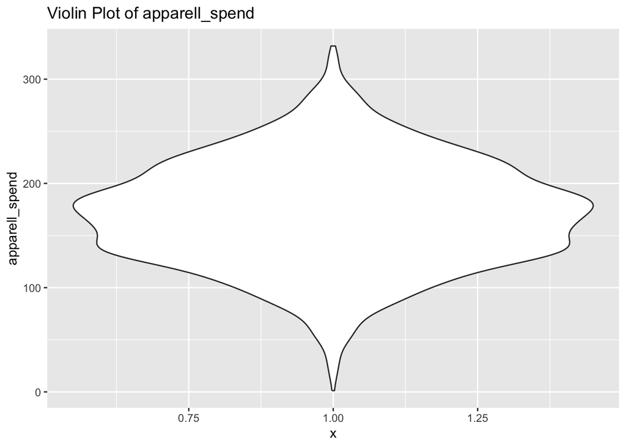

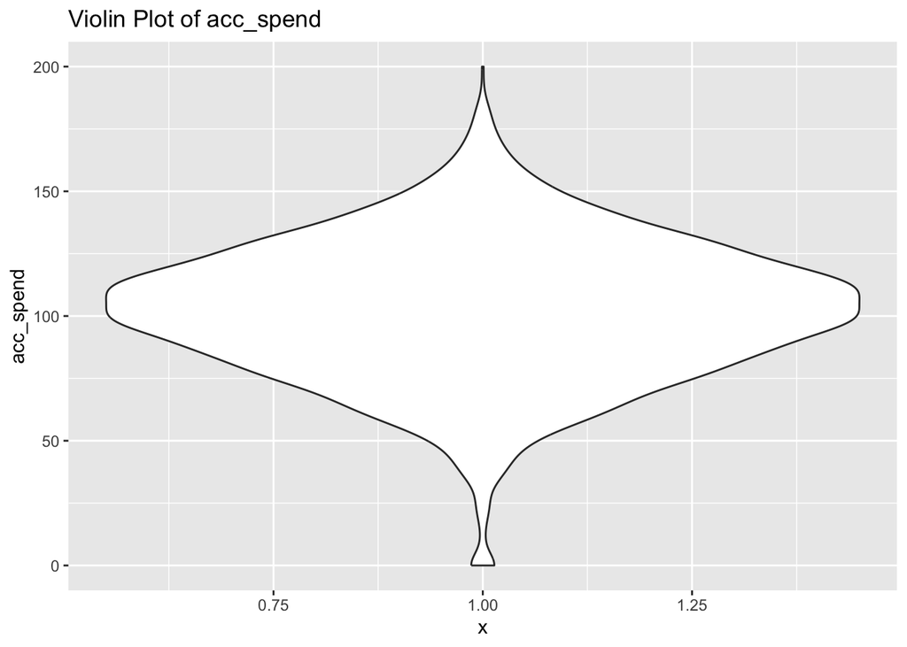

```r
# Continuous X variables' violin plots
continuous_cols <- c("last_purchase", "max_discount", "shoe_spend", "apparell_spend", "acc_spend")

for (continuous_x in continuous_cols) {

  p <- ggplot(customer_data, aes(x = 1, y = !!as.name(continuous_x))) +
    geom_violin() +
    labs(title = paste("Violin Plot of", continuous_x))
  print(p)
}
```

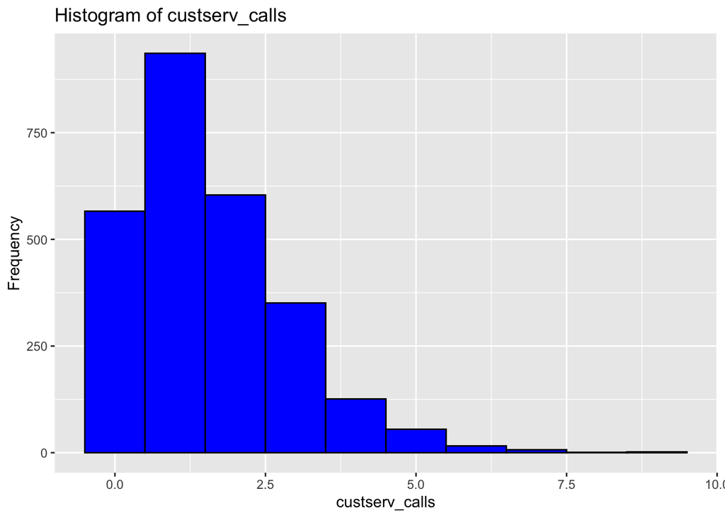

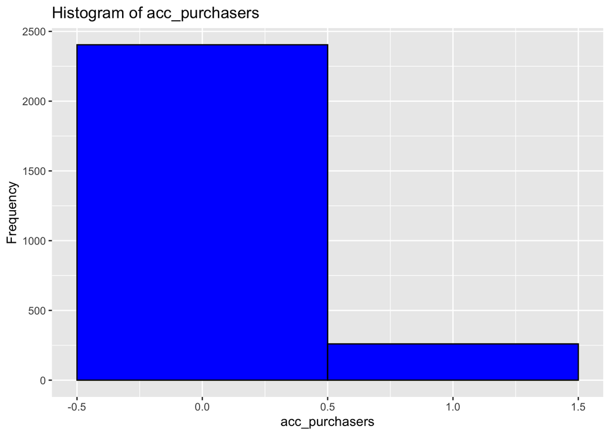

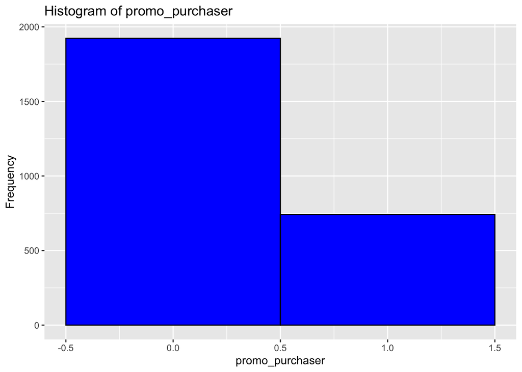

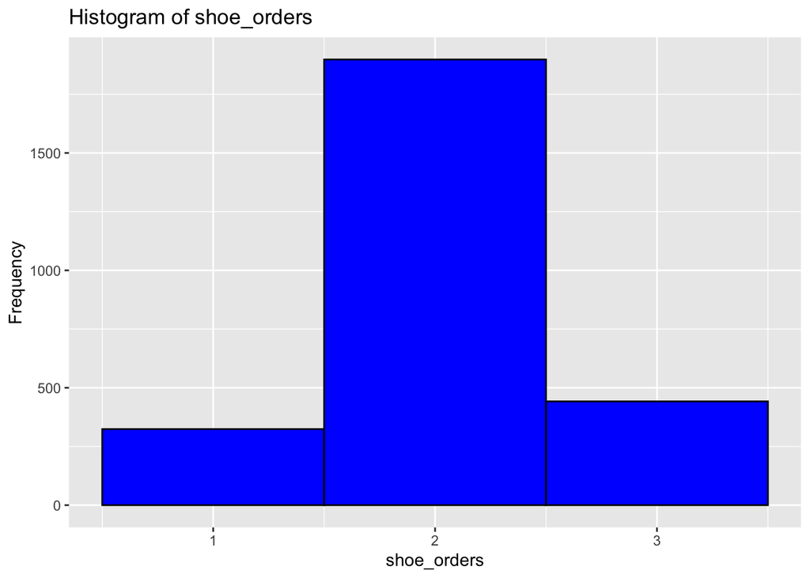

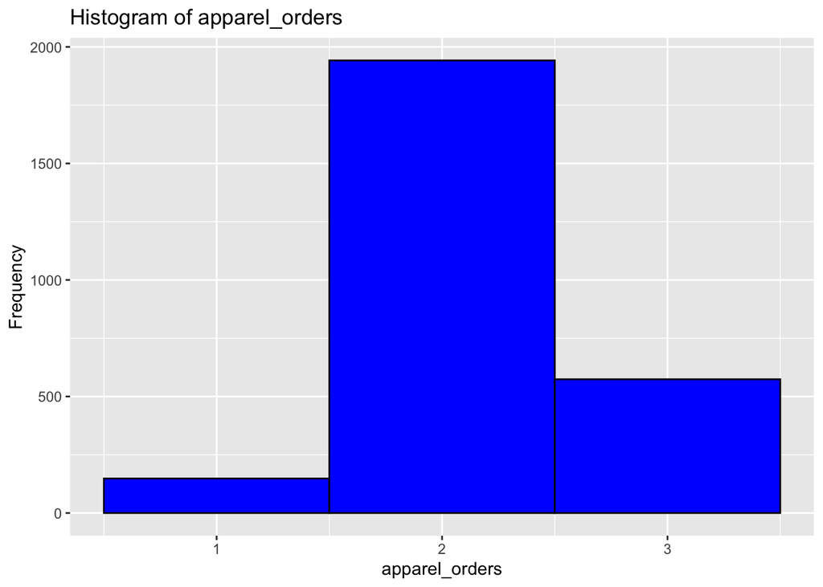

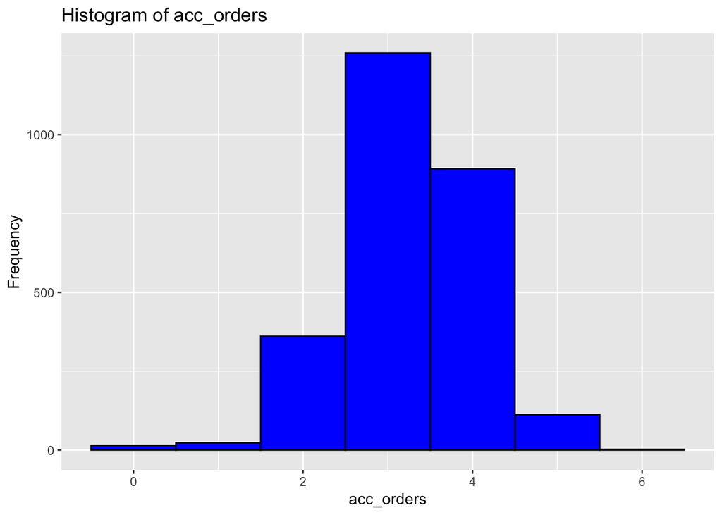

```r
# Integer-value X variables' histograms
integer_cols <- c("custserv_calls", "acc_purchasers", "promo_purchaser", "shoe_orders", "apparel_orders", "acc_orders")

for (integer_x in integer_cols) {
  p <- ggplot(customer_data, aes(x = !!as.name(integer_x))) +
    geom_histogram(binwidth = 1, fill = "blue", color = "black") +
    labs(
      title = paste("Histogram of", integer_x),
      x = integer_x,
      y = "Frequency"
    )
  print(p)
}
```

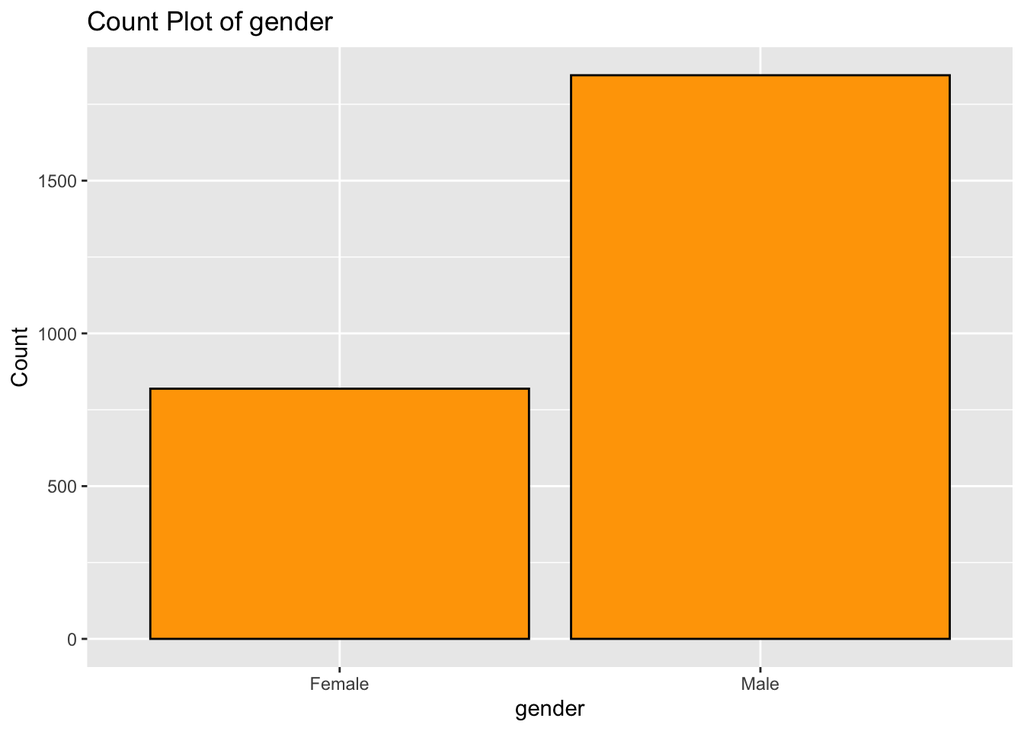

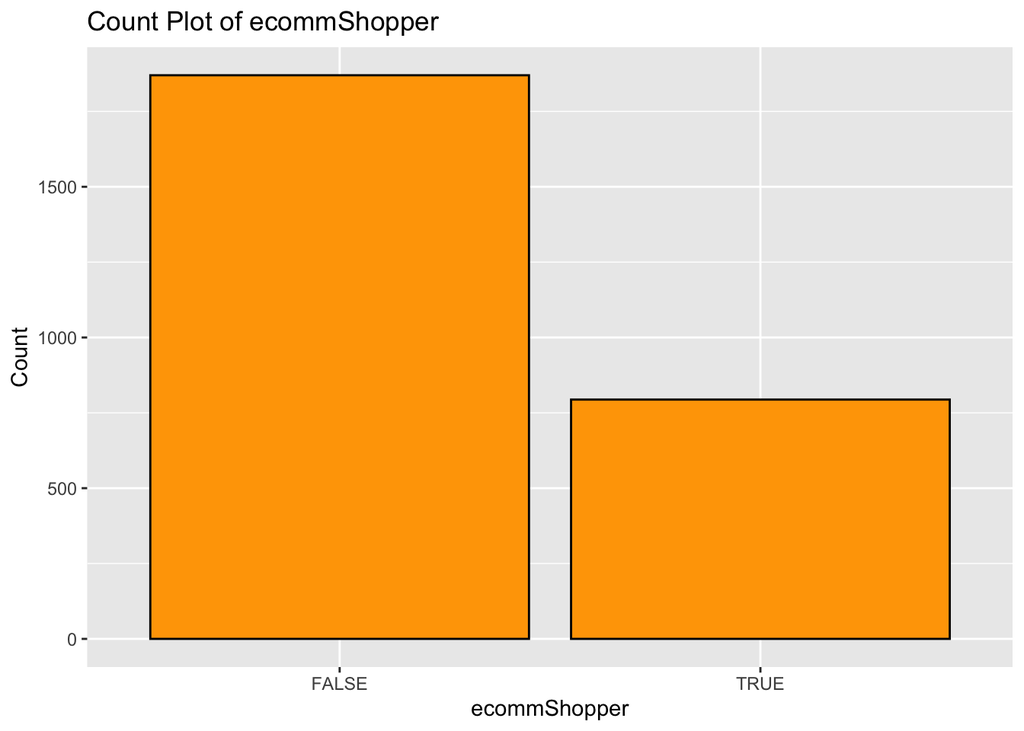

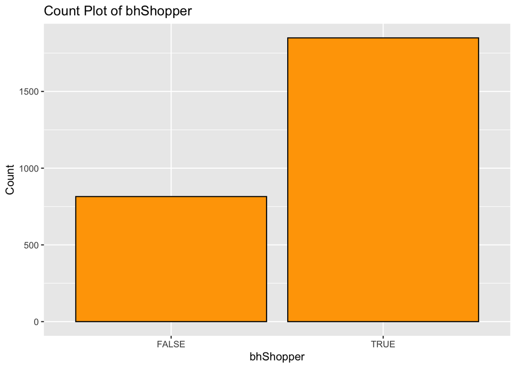

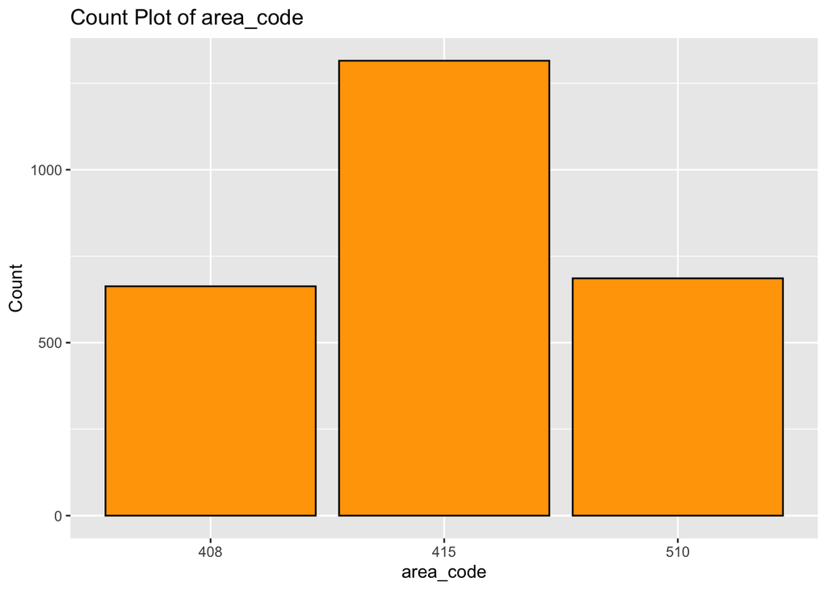

```r
# Convert area_code into categorical variable
customer_data$area_code <- as.character(customer_data$area_code)
customer_data$area_code <- as.factor(customer_data$area_code)

# Categorical X variables' count plots
categorical_cols <- c("gender", "ecommShopper", "bhShopper", "area_code")

for (categorical_x in categorical_cols) {
  p <- ggplot(customer_data, aes(x = !!as.name(categorical_x))) +
    geom_bar(fill = "orange", color = "black") +
    labs(
      title = paste("Count Plot of", categorical_x),
      x = categorical_x,
      y = "Count"
    )
  print(p)
}
```

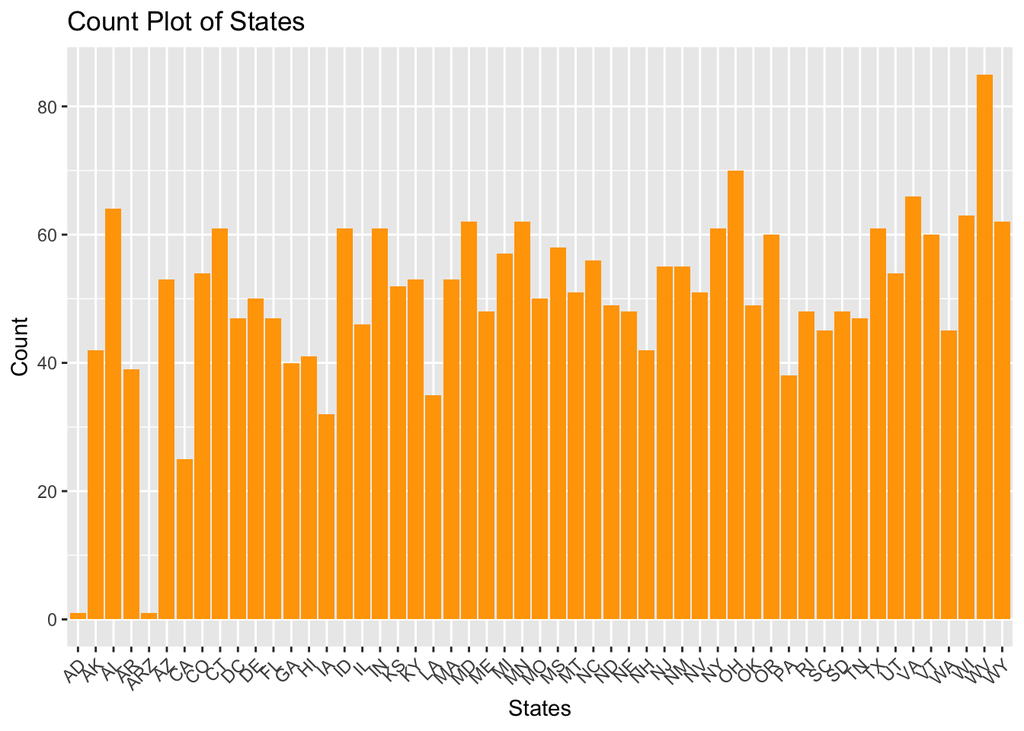

```r
p <- ggplot(customer_data, aes(x = state))+
  geom_bar(fill = "orange") +
  labs(
    title = "Count Plot of States",
    x = "States",
    y = "Count"
  ) +
  theme(axis.text.x = element_text(angle = 45, hjust = 1))
print(p)
```

Findings:

For “last_purchase”, “shoe_spend”, “apparell_spend”, and “acc_spend”, most observations are within a tight middle value range and few observations are low values or high values . For example, most “last_purchase” values are in 50 to 100 range and most “shoe_spend” values are in 150 to 350 range. The patterns are similar while the ranges are different.

For “max_discount”, most values are below 0.1, indicating that most maximum discounts are less than 10% and there are a small amount of 30% maximum discounts.

Most “custserv_calls” take on the value of 1 and it’s right-skewed. As the number of “custserv_calls” increases, there are fewer occurrences, which aligns with common sense if “custserv_calls” represents the number of times a customer called.

For “acc_purchasers” and ” promo_purchaser”, they both take on values of 0s and 1s, and most values are 0s.

Similarly, “shoe_orders”, ” apparel_orders”, and “acc_orders” take on several unique integer values. “shoe_orders” and ” apparel_orders” have similar trends and are clustered around 2 while most “acc_orders” values are 3 and 4.

For categorical variables, similarly, there are imbalanced categories in each variable. Gender male dominates “gender”, FALSE dominates “ecommShopper”, TRUE dominates “bhShopper” and 415 area code dominates “area_code”.

There are many categories in “state”. There are very few customers from states AD and ARZ and plenty of customers from state WV.

#### Y Variable “churn”

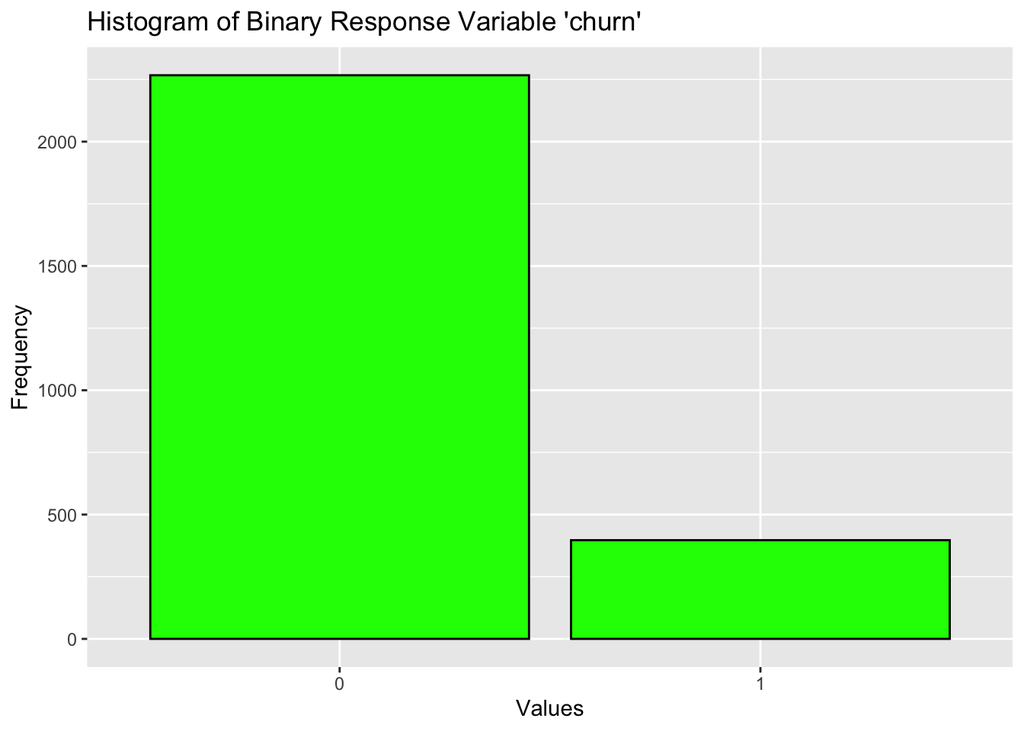

```r
# Turn "churn" variable into categorical.
customer_data$churn <- as.character(customer_data$churn)

p <- ggplot(customer_data, aes(x = churn)) +
  geom_bar( fill = "green", color = "black") +
  labs(
    title = "Histogram of Binary Response Variable 'churn'",
    x = "Values",
    y = "Frequency"
  )
print(p)
```

```r
prop_0_to_1 <- sum(customer_data$churn == "0") / sum(customer_data$churn == "1")
print(prop_0_to_1)
```

```
## [1] 5.710327
```

Since the proportion of 0s to 1s in ‘churn’ is 5.7 : 1, there is little need to apply oversampling or under-sampling.

### Bivariate Analysis

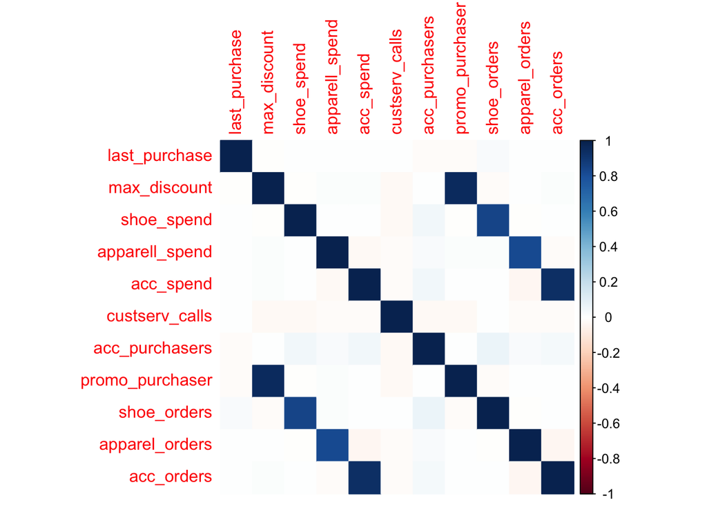

```r
# Create correlation plot to see correlations between explanatory continuous X variables
correlation_data <- customer_data %>%
  select_if(is.numeric)

correlation_matrix <- cor(correlation_data)
corrplot(correlation_matrix, method = "color")
```

Reasonably, there are four pairs of variables that are highly-correlated with each other: “shoe_orders” and “shoe_spend”, “acc_orders” and “acc_spend”, “promo_purchaser” and “max_discount”, “apparel_orders” and “apparel_spend”. I would consider removing one of the two for these four pairs in the later data pre-processing section.

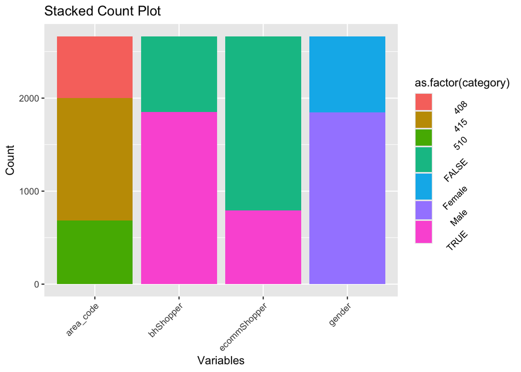

```r
# Create stacked count plot to see relationships between explanatory categorical X variables
categorical_data <- customer_data %>%
  select(gender, ecommShopper, bhShopper, area_code)

categorical_data_long <- categorical_data %>%
  gather(variable, category)
category_counts <- categorical_data_long %>%
  group_by(variable, category) %>%
  summarize(count = n())
p <- ggplot(category_counts, aes(x = variable, y = count, fill = as.factor(category))) +
  geom_bar(stat = "identity") +
  labs(
    title = "Stacked Count Plot",
    x = "Variables",
    y = "Count"
  ) +
  theme(axis.text.x = element_text(angle = 45, hjust = 1)) +
  theme(legend.text = element_text(angle = 45, hjust = 1)) +
  theme(legend.position = "right")
print(p)
```

Findings:

There are category imbalances in the distributions of “area_code”, “bhShopper”, “ecommShopper”, and “gender”.

```r
# Use GROUPBY to further analyze relationships between explanatory categorical X variables

areacode_bhShopper <- customer_data %>%
  group_by(area_code, bhShopper) %>%
  summarize(count = n())
print(areacode_bhShopper)
```

```
## # A tibble: 6 × 3
## # Groups:   area_code [3]
##   area_code bhShopper count
##   <fct>     <lgl>     <int>
## 1 408       FALSE       201
## 2 408       TRUE        462
## 3 415       FALSE       407
## 4 415       TRUE        908
## 5 510       FALSE       207
## 6 510       TRUE        479
```

```r
areacode_ecommShopper <- customer_data %>%
  group_by(area_code, ecommShopper) %>%
  summarize(count = n())
print(areacode_ecommShopper)
```

```
## # A tibble: 6 × 3
## # Groups:   area_code [3]
##   area_code ecommShopper count
##   <fct>     <lgl>        <int>
## 1 408       FALSE          452
## 2 408       TRUE           211
## 3 415       FALSE          922
## 4 415       TRUE           393
## 5 510       FALSE          496
## 6 510       TRUE           190
```

```r
gender_ecommShopper <- customer_data %>%
  group_by(gender, ecommShopper) %>%
  summarize(count = n())
print(gender_ecommShopper)
```

```
## # A tibble: 4 × 3
## # Groups:   gender [2]
##   gender ecommShopper count
##   <chr>  <lgl>        <int>
## 1 Female FALSE          557
## 2 Female TRUE           262
## 3 Male   FALSE         1313
## 4 Male   TRUE           532
```

```r
gender_bhShopper <- customer_data %>%
  group_by(gender, bhShopper) %>%
  summarize(count = n())
print(gender_bhShopper)
```

```
## # A tibble: 4 × 3
## # Groups:   gender [2]
##   gender bhShopper count
##   <chr>  <lgl>     <int>
## 1 Female FALSE       243
## 2 Female TRUE        576
## 3 Male   FALSE       572
## 4 Male   TRUE       1273
```

Findings:

In all three areas, there are doubled number of bhShoppers than that of non-bhShoppers.

In all three areas, there are doubled or tripled number of non-ecommShoppers than that of ecommShoppers.

So differences in areas don’t affect “bhShopper” and “ecommShopper” much.

70% of women are bhShoppers and 69% of men are bhShoppers so “gender” doesn’t affect “bhShopper” much.

### XY Relationships Analysis

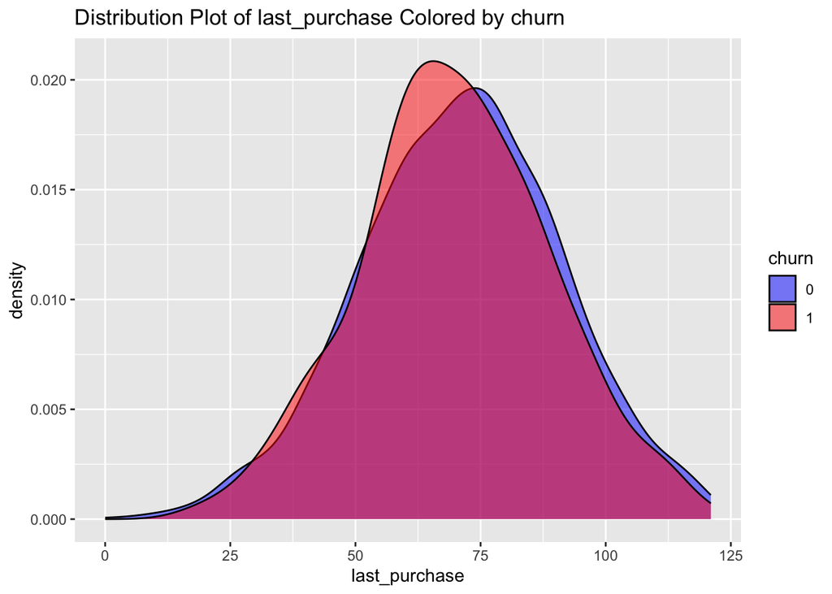

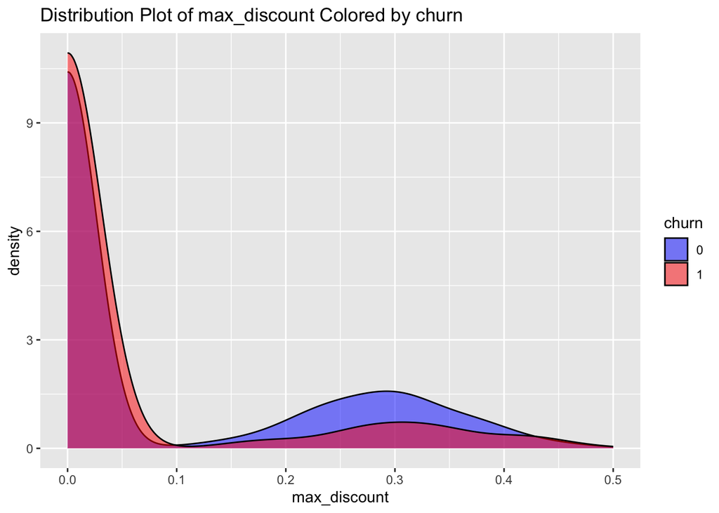

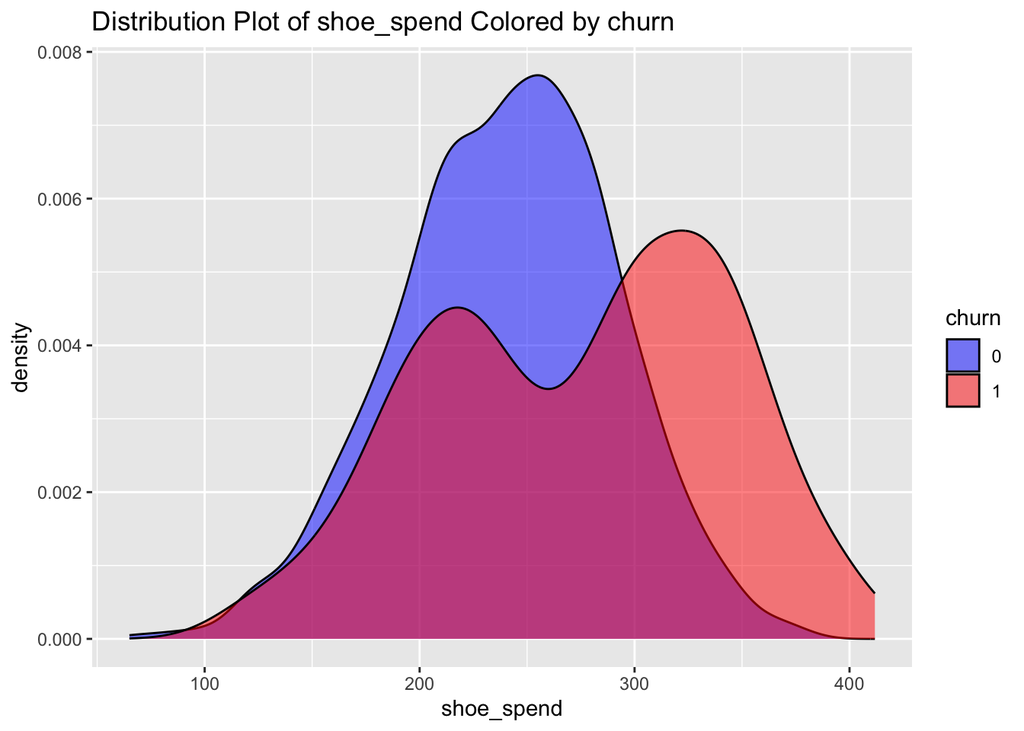

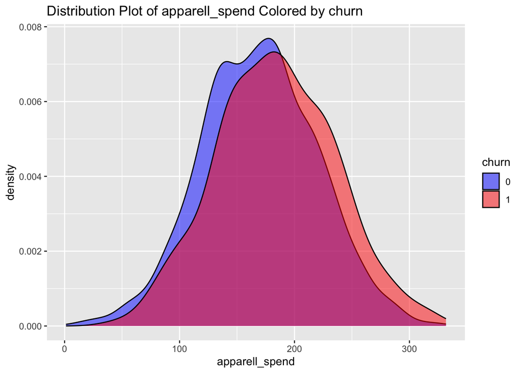

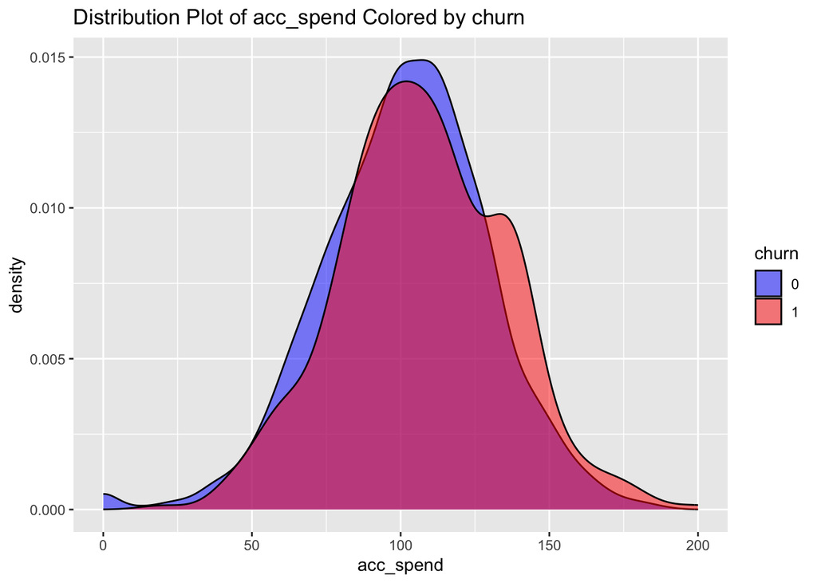

```r
# Distribution plots of numerical x variables by dependent variable "churn"
for (x_var in continuous_cols) {
  p <- ggplot(customer_data, aes(x = !!as.name(x_var), fill = factor(customer_data$churn))) +
    geom_density(alpha = 0.5) +
    labs(
      title = paste("Distribution Plot of", x_var, "Colored by churn"),
      x = x_var
    ) +
    scale_fill_manual(values = c("0" = "blue", "1" = "red"),
                      name = "churn")
  print(p)
}
```

Findings:

For “last_purchase”, “apparell_spend”, and “acc_spend”, the overall trends for churns and no-churns are almost the same with some differences in certain range. For example, for last_purchase within range 50 to 75, there are obviously more churns than no-churns; for “apparell_spend”, the two curves have similar shape but churn curve shifts slightly to the right.

For “max_discount” and “shoe_spend”, there are obvious differences between curves, indicating the impact of these two variables on the dependent churn variable.

In conclusion, all of these variables above could explain our Y variable “churn” to some extent.

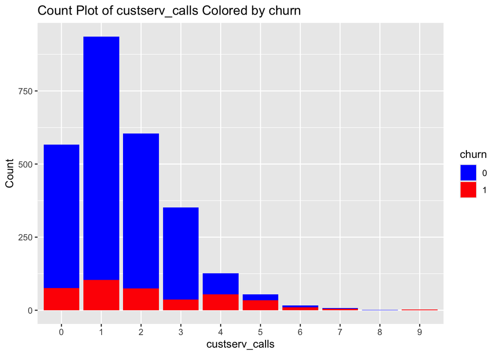

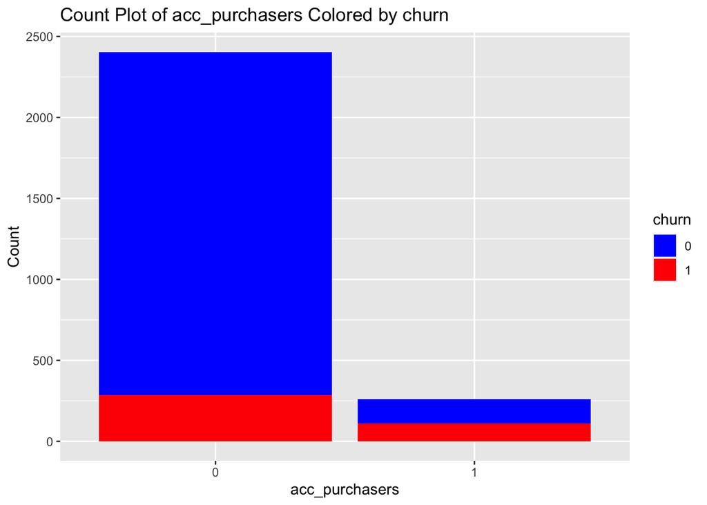

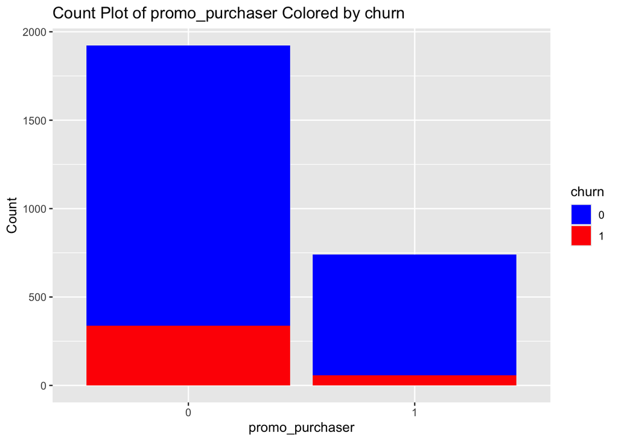

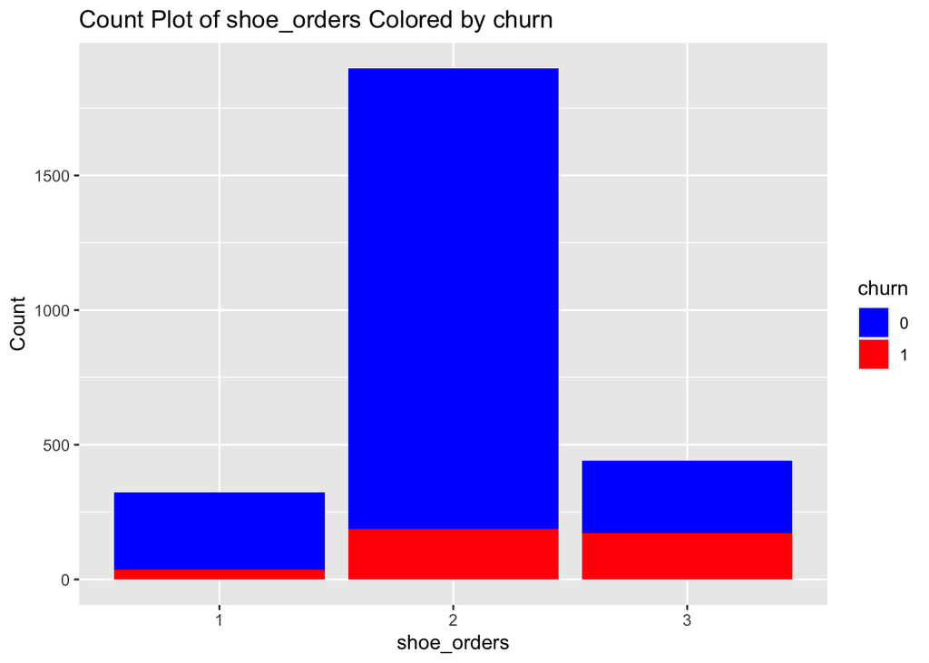

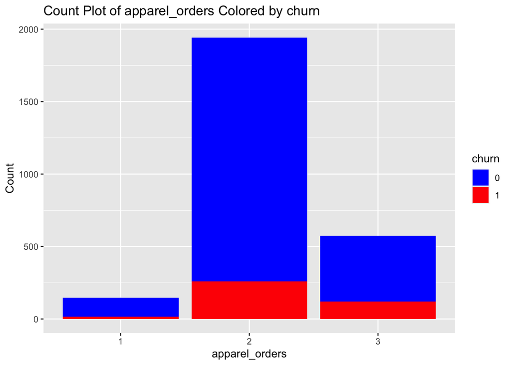

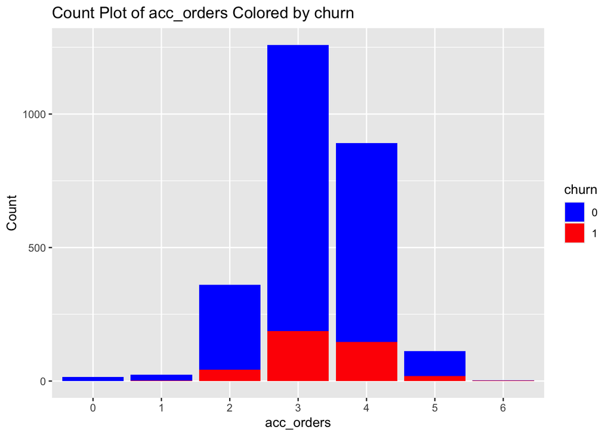

```r
# Count plots of categorical x variables colored by dependent 'churn' variable

for (int_var in integer_cols) {
  p <- ggplot(customer_data, aes(x = factor(!!as.name(int_var)), fill = factor(customer_data$churn))) +
    geom_bar() +
    labs(
      title = paste("Count Plot of", int_var, "Colored by churn"),
      x = int_var,
      y = "Count"
    ) +
    scale_fill_manual(values = c("0" = "blue", "1" = "red"), name = "churn")
  print(p)
}
```